# FigureYa160scGSVA

**Author(s)**: Jinen Song  
**Reviewer(s)**: Ying Ge, Junyi Shen  
**Date**: 2025-09-22

# Academic Citation

If you use this code in your work or research, we kindly request that you cite our publication:

Xiaofan Lu, et al. (2025). FigureYa: A Standardized Visualization Framework for Enhancing Biomedical Data Interpretation and Research Efficiency. iMetaMed. https://doi.org/10.1002/imm3.70005

# 需求描述

# Requirement

对单细胞亚群进行功能注释后，如何求每群细胞某条pathway的gene set score After functionally annotating single-cell subpopulations, how can I calculate the gene set score for a specific pathway in each subpopulation?

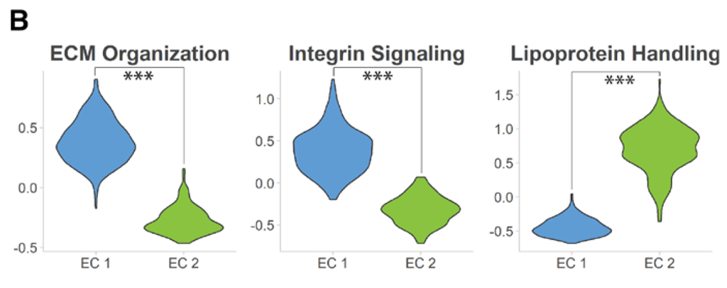

出自https://www.ahajournals.org/doi/10.1161/CIRCULATIONAHA.118.038362 From https://www.ahajournals.org/doi/10.1161/CIRCULATIONAHA.118.038362

Figure 5. Pathway analysis of endothelial cell (EC) subpopulations. B, Functional gene sets identified from Reactome pathway enrichment and subpopulation markers differentiate the 2 major EC populations EC 1 and EC 2.

# 应用场景

# Application Scenario

单细胞数据，从matrix到分组，用GSVA计算pathway的表达量，然后比较pathway在组间的差异，画图。 Single-cell data: From matrix to grouping, calculate pathway expression using GSVA, then compare pathway differences between groups and plot.

# 环境设置

# Environment Setup

```r
source("install_dependencies.R")
```

[output not shown]

[output cut: 27 more lines]

[output not shown]

```r
library(dplyr)
```

```r
library(Seurat)
library(ComplexHeatmap)
library(GSVA)
library(GSEABase)
library(limma)
library(ggplot2)
Sys.setenv(LANGUAGE = "en") #显示英文报错信息 # Display English error messages
options(stringsAsFactors = FALSE) #禁止chr转成factor # Disable conversion of chr to factor
```

加载自定义函数 Loading custom functions

做单细胞分析时，代码会非常多而且繁杂，为了脚本的整洁简短，我们把这些函数单独放在一个文件里，使用时导入就可以了。 Single-cell analysis can be quite complex and tedious. To keep the script concise, we’ll place these functions in a separate file and import them when needed.

```r
source("seurat_pipeline.R")
```

# 输入文件

# Input files

输入文件位于文件夹：pbmc3k_filtered_gene_bc_matrices/filtered_gene_bc_matrices/hg19/，包括raw gene expression matrix、barcode和gene annotation。 The input files are located in the folder: pbmc3k_filtered_gene_bc_matrices/filtered_gene_bc_matrices/hg19/ and include the raw gene expression matrix, barcodes, and gene annotations.

数据来源：https://s3-us-west-2.amazonaws.com/10x.files/samples/cell/pbmc3k/pbmc3k_filtered_gene_bc_matrices.tar.gz Data source: https://s3-us-west-2.amazonaws.com/10x.files/samples/cell/pbmc3k/pbmc3k_filtered_gene_bc_matrices.tar.gz

```r
pbmc.data <- Read10X(data.dir = "pbmc3k_filtered_gene_bc_matrices/filtered_gene_bc_matrices/hg19/")
# Initialize the Seurat object with the raw (non-normalized data).
pbmc <- CreateSeuratObject(counts = pbmc.data, project = "pbmc3k", min.cells = 3, min.features = 200)
pbmc
```

```
## An object of class Seurat
## 13714 features across 2700 samples within 1 assay
## Active assay: RNA (13714 features, 0 variable features)
##  1 layer present: counts
```

主要步骤： Main steps:

- STEP 1 : 对单细胞数据进行分组，获得分组信息
- STEP 2 : 进行GSVA分析、差异表达分析
- STEP 3 : 根据已经得到的分组信息，挑选感兴趣的通路，画图
- STEP 1: Group the single-cell data and obtain group information
- STEP 2: Perform GSVA analysis and differential expression analysis
- STEP 3: Based on the obtained grouping information, select the pathway of interest and draw a graph

# STEP 1: 对单细胞数据进行分组，获得分组信息

# STEP 1: Group the single-cell data and obtain grouping information

用于从raw gene expression matrix开始。 Used to start from the raw gene expression matrix.

如果已经完成了聚类，请移动到STEP 2。 If clustering has been completed, please move to STEP 2.

使用seurat分析单细胞数据需要注意的几个地方: Several points to note when using Seurat to analyze single-cell data:

## 1. 数据过滤

## 1. Data filtering

1. 细胞内表达基因个数 <200 或 > 7500的过滤掉。这里过滤的上限和下限自己把控，没有固定值。过滤掉基因表达高的是为了减少多细胞比例
2. Filter out cells with <200 or >7500 expressed genes. The upper and lower limits of the filter are controlled by yourself and there is no fixed value. Filtering out genes with high expression is to reduce the proportion of multiple cells
3. 在 <3 个细胞内有表达的基因，过滤掉。因为很多基因的表达值都是0，这种可以过滤掉很多表达全为0的基因
4. Filter out genes that are expressed in <3 cells. Because many genes have an expression value of 0, this method can filter out many genes with all zero expressions
5. 线粒体基因比例，一定程度上代表这建库时细胞的完整性。如果线粒体基因比例太高，说明细胞非常有可能破损了，在油包水时就不完整了
6. The proportion of mitochondrial genes, to a certain extent, represents the integrity of the cells when the library was built. If the mitochondrial gene ratio is too high, it’s very likely that the cells are damaged and incomplete during the oil-water mixture.

MT genes% < 20% 左右，根据自己的数据把控。就算这里过滤的不严格，也没有关系，后面聚类时，这些高线粒体基因比例的细胞都会聚到一类。 MT genes% < 20% or so. This should be controlled based on your data. Even if the filtering here is not strict, it doesn’t matter; cells with a high mitochondrial gene ratio will be clustered together during subsequent clustering.

后续分析时排除这些细胞就可以了。一般外周血数据中线粒体基因比例都很低。 These cells can simply be excluded from subsequent analysis. Mitochondrial gene ratios are generally very low in peripheral blood data.

## 2 聚类和降维可视化

## 2 Clustering and Dimensionality Reduction Visualization

这里有两个参数不好把控，一个是选择PCA结果中的PC个数，另一个就是resolution。 There are two parameters that are difficult to control: the number of PCs in the PCA results and the resolution.

- PC个数选择，可以根据ElbowPlot(拐点图)，选择拐点出现位置附近的PC数即可。这个参数会影响聚类的结果已经后续降维图形的。
- resolution：这个参数相对的不那么重要，只是会影响分出的cluster的数目多少。当resolution选的比较大，cluster分的很多，后续分析也可以
- For the number of PCs, select the number of PCs near the inflection point using the ElbowPlot (inflection point plot). This parameter affects the clustering results and subsequent dimensionality reduction graphs.
- Resolution: This parameter is relatively unimportant and only affects the number of clusters generated. A high resolution will result in a large number of clusters, which can be useful in subsequent analysis.

根据marker genes等，对细胞类型进行定义，然后人为的把相同细胞类型的cluster合并。 Define cell types based on marker genes and other factors, and then manually merge clusters of the same cell type.

一般细胞数目 5000 - 10000 左右时，选择 resolution = 1 都是可以的，细胞数量更多时可以选择2。自己根据分出的效果来调控，这个不影响大局。 Generally, for cells between 5,000 and 10,000, selecting resolution = 1 is sufficient. For larger cell numbers, you can choose 2. Adjust this setting based on the desired resolution; it does not affect the overall result.

## 用自定义函数`Seurat.pipeline`做预处理

## Preprocessing with the Custom `Seurat.pipeline` Function

整个过程中需要调整的就只有这几个参数了： The only parameters that need to be adjusted during the entire process are:

```r
Seurat.pipeline(RdsName = pbmc, outputname = "PBMC", MTfraction = 0.05, pc = 10, res = 0.6)
```

```
## Normalizing layer: counts
```

```
## Finding variable features for layer data
```

```
## Modularity Optimizer version 1.3.0 by Ludo Waltman and Nees Jan van Eck
##
## Number of nodes: 2643
## Number of edges: 97538
##
## Running Louvain algorithm...
## Maximum modularity in 10 random starts: 0.8454
## Number of communities: 9
## Elapsed time: 0 seconds
```

[output not shown]

```r
# 这里需要运行几分钟
# 经过这一步的处理，现在在pbmc这个seurat object 的assays中存储了三种基因表达数据，保存在PBMC_pc10_res0.6.rds里
# (1) pbmc@assays$RNA@counts : raw count
# (2) pbmc@assays$RNA@data : Normalized data
# (3) pbmc@assays$RNA@scale.data: scaled之后的data
# 做GSVA分析时，使用normalized data就可以了.
# This will take several minutes to run
# After this step, three types of gene expression data are now stored in the assays of the seurat object pbmc, saved in PBMC_pc10_res0.6.rds
# (1) pbmc@assays$RNA@counts : raw counts
# (2) pbmc@assays$RNA@data : Normalized data
# (3) pbmc@assays$RNA@scale.data: scaled data
# When performing GSVA analysis, use normalized data.
```

提取出每个细胞的基因表达量和对应的分组信息。 Extract the gene expression level of each cell and the corresponding group information.

> 查看生成的`PBMC_pc10_res0.6.pdf`文件，分成了9个cluster View the generated `PBMC_pc10_res0.6.pdf` file, which is divided into 9 clusters.

如何鉴定每个cluster是什么细胞类型？经典的做法是找出每个cluster中的高表达的基因，然后根据经典的细胞marker来确定细胞类型，需要查找文献。方法见官网https://satijalab.org/seurat/v3.1/pbmc3k_tutorial.html How do you identify the cell type of each cluster? The classic approach is to identify the most highly expressed genes in each cluster and then determine the cell type based on classic cell markers. This requires research. For methods, see the official website https://satijalab.org/seurat/v3.1/pbmc3k_tutorial.html

# STEP 2 : GSVA 分析和差异表达分析

# STEP 2: GSVA Analysis and Differential Expression Analysis

选择感兴趣的两个细胞亚群（cluster），用GSVA算出pathway的表达量，然后对比，画出感兴趣的pathway的图。 Select two cell subpopulations (clusters) of interest, calculate pathway expression using GSVA, compare them, and plot the pathway of interest.

```r
# 加载 STEP 1 获得的pbmc / Load PBMC obtained in Step 1
pbmc <- readRDS("PBMC_pc10_res0.6.rds")

# 导入gmt文件 / Import gmt file
genesets <- getGmt("h.all.v7.0.symbols.gmt")

### 1. 找到感兴趣的细胞组别，两者间进行比较 / Find cell groups of interest and compare them
subcluster <- c(6, 8)
sub <- subset(pbmc, idents = subcluster)
df.data <- GetAssayData(object = sub, slot = "data")

# 将细胞所属的group信息保存起来 / Save cell group information
df.group <- data.frame(
  umi = names(Idents(sub)),
  cluster = as.character(sub@meta.data$RNA_snn_res.0.6),
  stringsAsFactors = FALSE
)

### 2. 做gsva - 修复参数传递问题 / Perform GSVA - fix parameter passing issues
# 确保数据格式正确 / Ensure correct data format
expr_data <- as.matrix(df.data)

# 转换genesets为gsva需要的格式 / Convert genesets to the format required by gsva
# GSEABase::getGmt()返回的是GeneSetCollection对象，需要转换为列表
geneset_list <- lapply(genesets, function(gs) {
  GSEABase::geneIds(gs)
})
names(geneset_list) <- names(genesets)

# 使用正确的参数格式调用gsva / Call gsva with correct parameter format
param <- gsvaParam(
  exprData = expr_data,
  geneSets = geneset_list,
  kcdf = "Gaussian"
)

gsvascore <- gsva(
  param,
  verbose = TRUE
)
```

```
## ℹ GSVA version 2.2.0
```

```
## ! 3208 genes with constant values throughout the samples
```

```
## ! Genes with constant values are discarded
```

```
## ℹ Calculating GSVA ranks
```

```
## ℹ GSVA dense (classical) algorithm
```

```
## ℹ Row-wise ECDF estimation with Gaussian kernels
```

```
## ℹ Calculating GSVA column ranks
```

```
## ℹ Calculating GSVA scores
```

```
## ✔ Calculations finished
```

```r
# 查看结果 / Check results
print("GSVA score dimensions: / GSVA得分维度:")
```

```
## [1] "GSVA score dimensions: / GSVA得分维度:"
```

```r
print(dim(gsvascore))
```

```
## [1]  50 158
```

```r
print(gsvascore[1:5, 1:5])
```

```
##                                     AAACCGTGTATGCG-1 AACCTTACGCGAGA-1
## HALLMARK_TNFA_SIGNALING_VIA_NFKB        -0.084042406      -0.04750403
## HALLMARK_HYPOXIA                        -0.275733700      -0.02419425
## HALLMARK_CHOLESTEROL_HOMEOSTASIS        -0.184139316      -0.02805247
## HALLMARK_MITOTIC_SPINDLE                -0.007267611      -0.02267195
## HALLMARK_WNT_BETA_CATENIN_SIGNALING      0.036409789      -0.11564992
##                                     AACGCCCTCGTACA-1 AACGTCGAGTATCG-1
## HALLMARK_TNFA_SIGNALING_VIA_NFKB         -0.01915613       0.01932358
## HALLMARK_HYPOXIA                         -0.17882515      -0.06931369
## HALLMARK_CHOLESTEROL_HOMEOSTASIS         -0.31405915       0.04954620
## HALLMARK_MITOTIC_SPINDLE                  0.03081070      -0.09686088
## HALLMARK_WNT_BETA_CATENIN_SIGNALING      -0.14104335      -0.21767117
##                                     AAGATTACCTCAAG-1
## HALLMARK_TNFA_SIGNALING_VIA_NFKB          0.11589551
## HALLMARK_HYPOXIA                          0.02013400
## HALLMARK_CHOLESTEROL_HOMEOSTASIS         -0.25018134
## HALLMARK_MITOTIC_SPINDLE                 -0.18018603
## HALLMARK_WNT_BETA_CATENIN_SIGNALING      -0.09784563
```

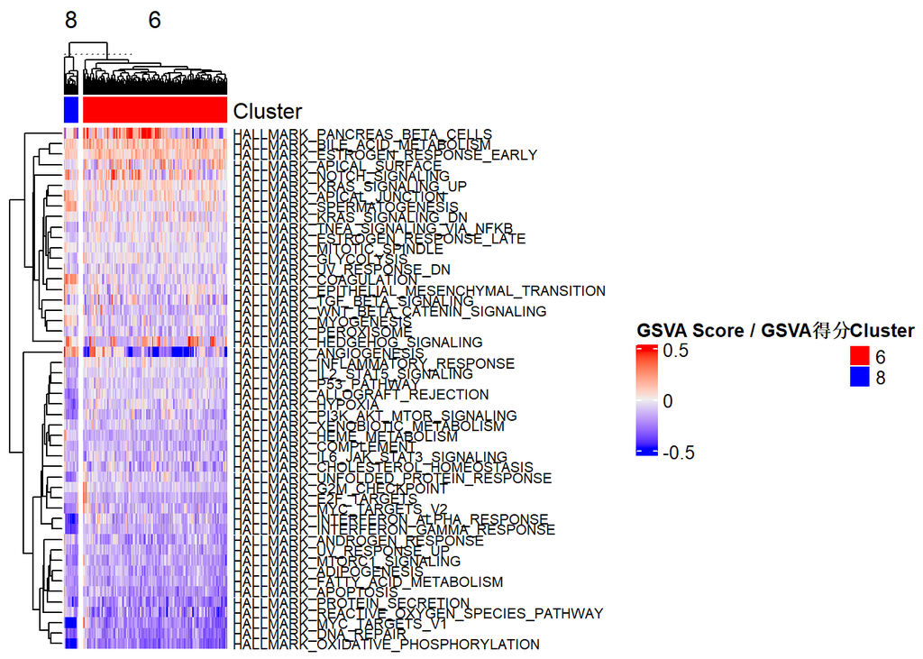

```r
### 3. 绘制热图 / Draw heatmap
# 确保分组信息与列名匹配 / Ensure group information matches column names
if (ncol(gsvascore) == nrow(df.group)) {
  # 确保安装了ComplexHeatmap包
  if (!require(ComplexHeatmap)) {
    install.packages("ComplexHeatmap")
    library(ComplexHeatmap)
  }

  ha.t <- HeatmapAnnotation(
    Cluster = df.group$cluster,
    col = list(Cluster = c("6" = "red", "8" = "blue"))
  )

  # 绘制热图 / Draw heatmap
  heatmap_plot <- Heatmap(
    as.matrix(gsvascore),
    show_column_names = FALSE,
    cluster_rows = TRUE,
    cluster_columns = TRUE,
    top_annotation = ha.t,
    column_split = df.group$cluster,
    row_names_gp = gpar(fontsize = 8),
    row_names_max_width = max_text_width(
      rownames(gsvascore),
      gp = gpar(fontsize = 8)
    ),
    name = "GSVA Score / GSVA得分"
  )

  print(heatmap_plot)
} else {
  print("Warning: GSVA score dimensions don't match group information / 警告: GSVA得分维度与分组信息不匹配")
  print(paste("GSVA columns: / GSVA列数:", ncol(gsvascore)))
  print(paste("Group rows: / 分组行数:", nrow(df.group)))
}
```

```r
### 4. 差异分析 / Differential analysis
cluster.group <- as.numeric(df.group$cluster)
group2 <- 6
cluster.group[cluster.group != group2] <- 0
cluster.group[cluster.group == group2] <- 1

design <- model.matrix(~ cluster.group)
colnames(design) <- c("Intercept", "Group2vs1")

# 使用limma进行差异分析 / Perform differential analysis using limma
if (!require(limma)) {
  install.packages("limma")
  library(limma)
}

fit <- lmFit(gsvascore, design)
fit <- eBayes(fit)

# 获取显著通路 / Get significant pathways
sigPathways <- topTable(
  fit,
  coef = "Group2vs1",
  number = Inf,
  p.value = 0.05,
  adjust.method = "BH"
)

# 添加分组信息 / Add grouping information
if (nrow(sigPathways) > 0) {
  sigPathways$celltype <- rep(group2, nrow(sigPathways))

  # 保存结果 / Save results
  write.csv(
    sigPathways,
    file = "PBMC_DE_genesets_hallmarker_cluster6_vs_8.csv",
    row.names = TRUE
  )

  print(paste("Found / 发现", nrow(sigPathways), "significant pathways / 个显著通路"))
  print(head(sigPathways))
} else {
  print("No significant pathways found with p.value < 0.05 / 未发现p值<0.05的显著通路")
}
```

```
## [1] "Found / 发现 27 significant pathways / 个显著通路"
##                                         logFC     AveExpr          t
## HALLMARK_COAGULATION               -0.2840298 -0.02811124 -10.345486
## HALLMARK_INTERFERON_GAMMA_RESPONSE  0.2121854 -0.16343340   9.151296
## HALLMARK_ALLOGRAFT_REJECTION        0.1956983 -0.08655707   8.800848
## HALLMARK_MYC_TARGETS_V1             0.2458436 -0.25823635   7.692880
## HALLMARK_INTERFERON_ALPHA_RESPONSE  0.2651637 -0.14091760   7.485877
## HALLMARK_HEME_METABOLISM           -0.1436523 -0.13353726  -7.056781
##                                         P.Value    adj.P.Val        B celltype
## HALLMARK_COAGULATION               1.367351e-19 6.836753e-18 33.81636        6
## HALLMARK_INTERFERON_GAMMA_RESPONSE 2.274688e-16 5.686720e-15 26.47941        6
## HALLMARK_ALLOGRAFT_REJECTION       1.910924e-15 3.184874e-14 24.37684        6
## HALLMARK_MYC_TARGETS_V1            1.307494e-12 1.634367e-11 17.93942        6
## HALLMARK_INTERFERON_ALPHA_RESPONSE 4.251966e-12 4.251966e-11 16.77903        6
## HALLMARK_HEME_METABOLISM           4.670975e-11 3.892479e-10 14.42389        6
```

# STEP 3：根据已经得到的分组信息，挑选出需要的通路，画图

# STEP 3: Based on the obtained grouping information, select the desired pathways and plot them.

从sigPathways中挑选一个gene set来展示例图的画法。你也可以写成循环，画多个。 Select a gene set from sigPathways to demonstrate how to plot an example plot. You can also create a loop to plot multiple plots.

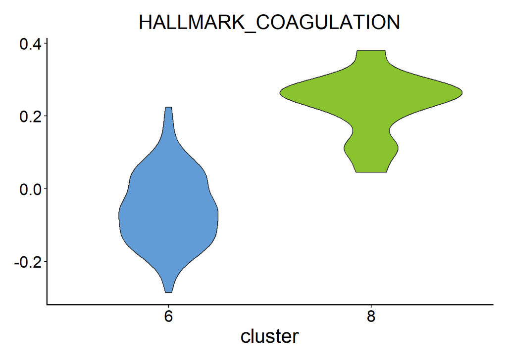

```r
# 这里选第一个pathway画图
# Select the first pathway to plot
count <- gsvascore[rownames(sigPathways)[1], , drop = FALSE]
count <- as.data.frame(t(count))
colnames(count) <- "geneset"
count$cluster <- as.character(Idents(sub))
# 用通路的名称作为图形标题
# Use the name of the pathway as the graph title
title.name = rownames(sigPathways)[1]

# 添加P值
# 得到cluster6和cluster10中的gsva score 最大值
# Add P value
# Get the maximum gsva score in cluster6 and cluster10
count.geneset.group1 <- count$geneset[count$cluster == subcluster[1]]
count.geneset.group2 <- count$geneset[count$cluster == subcluster[2]]

# 确定P值添加的位置
# Determine the position to add the P value
ysegment1 <- max(count.geneset.group1)
ysegment2 <- max(count.geneset.group2)
ysegment.max <- max(ysegment1, ysegment2)

# 根据P值确定加几颗星
# Add stars based on P value
pval <- sigPathways$P.Value[1]

if (pval < 0.001) {
  pval.label = "***"
} else if (pval < 0.005) {
  pval.label = "**"
} else if (pval < 0.05) {
  pval.label = "*"
} else if (pval >= 0.05) {
  pval.label = "non.sig"
}

# 自定义颜色
# Custom color
blue <- "#619CD6"
green <- "#89C32E"
p <- ggplot(count, aes(x = cluster, y = geneset, fill = cluster)) +
  geom_violin() +
  scale_fill_manual(values = c(blue, green)) + # 用自定义颜色填充 # Fill with custom color
  theme_classic() +
  theme(panel.grid = element_blank(),
        plot.margin = margin(0.5, 0.5, 0.5, 0.5, "cm"),
        axis.title.x = element_text(color = "black", size = 20),
        axis.title.y = element_blank(),
        axis.text = element_text(color = "black", size = 16),
        axis.line = element_line(colour = "black", size = 0.6),
        plot.title = element_text(size = 20, hjust = 0.5)) +
  # 添加图形标题 # Add graph title
  ggtitle(title.name) +
  guides(fill = F)
p
```

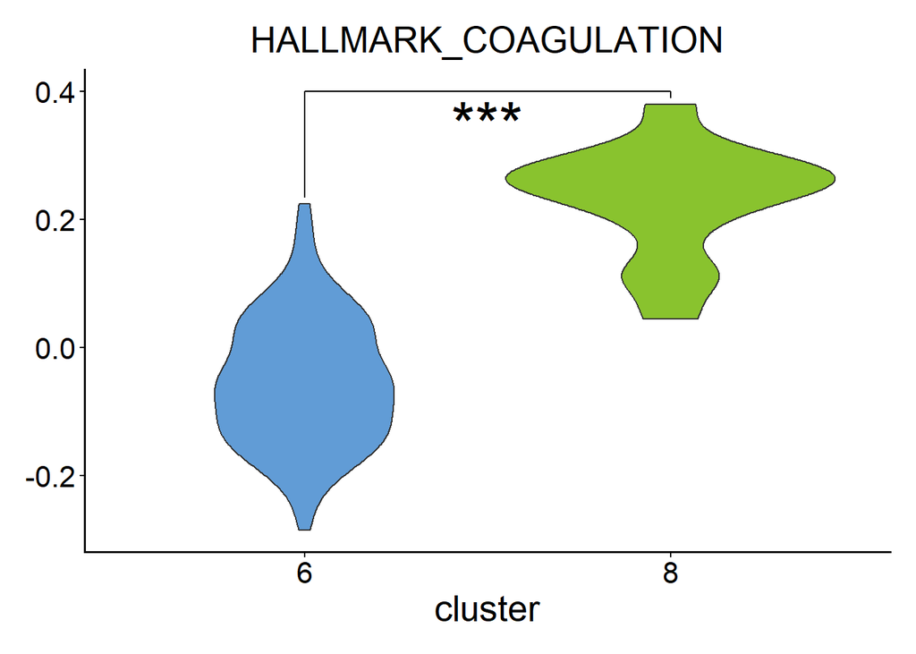

```r
# 前面已经得到了pvalue,添加上去就可以了
# We already got the pvalue, so just add it.
p +
  # 图形中的一个横线和两个竖线 # One horizontal line and two vertical lines in the graph
  annotate("segment", x = 1, xend = 2, y = ysegment.max + 0.02, yend = ysegment.max + 0.02) +
  annotate("segment", x = 1, xend = 1, y = ysegment1 + 0.01, yend = ysegment.max + 0.02) +
  annotate("segment", x = 2, xend = 2, y = ysegment2 + 0.01, yend = ysegment.max + 0.02) +
  # 添加P值对应的星号 # Add asterisks for P values
  annotate("text",
           size = 12, # *的大小 # Size of the *
           x = 1.5,
           y = ysegment.max - 0.03, #可以微调*所在的位置 # You can fine-tune the position of the *
           label = pval.label)
```

```r
ggsave("PBMC_DE_genesets_hallmarker_cluster6_vs_8.pdf", width = 5.5, height = 5)
```